# Practical Machine Learning Assignment

Martin Thomas

September 14, 2014

# Executive Summary

The quantified self movement (a group of enthusiasts who take measurements about themselves regularly to improve their health) attempt to find patterns in their behavior. They regularly quantify how much of a particular activity is done, but rarely how well it is done. In this project, we will use data from accelerometers on the belt, forearm, arm, and dumbell of 6 participants. They were asked to perform barbell lifts correctly and incorrectly in 5 different ways.

We will show that we can predict the manner in which the exercise is done using the dataset provided.

# Processing

Let’s begin with loading the data

```r
library(caret)
rawTrain <- read.csv('pml-training.csv', na.strings=c("NA",""), strip.white=T)
rawTest <- read.csv('pml-testing.csv', na.strings=c("NA",""), strip.white=T)
```

Now we remove the columns that have NA in them then remove timestamp or similar metadata

```r
realtrain <- rawTrain[,!sapply(rawTrain,function(x) any(is.na(x)))]
realtrain <- subset(realtrain, select=-c(X, user_name, new_window, num_window, raw_timestamp_part_1, raw_timestamp_part_2, cvtd_timestamp))
#str(realtrain)
#summary(realtrain)
#dim(realtrain)
```

Now split rawTrain into train and test sets

```r
inTrain <- createDataPartition(realtrain$classe, p=0.8, list=F)
training <- realtrain[inTrain,]
testing <- realtrain[-inTrain,]
```

# Exploratory Analysis

Plotting the correlation matrix is useful to give an idea of whether PCA would be helpful to reduce or remove variables that are highy correlated.

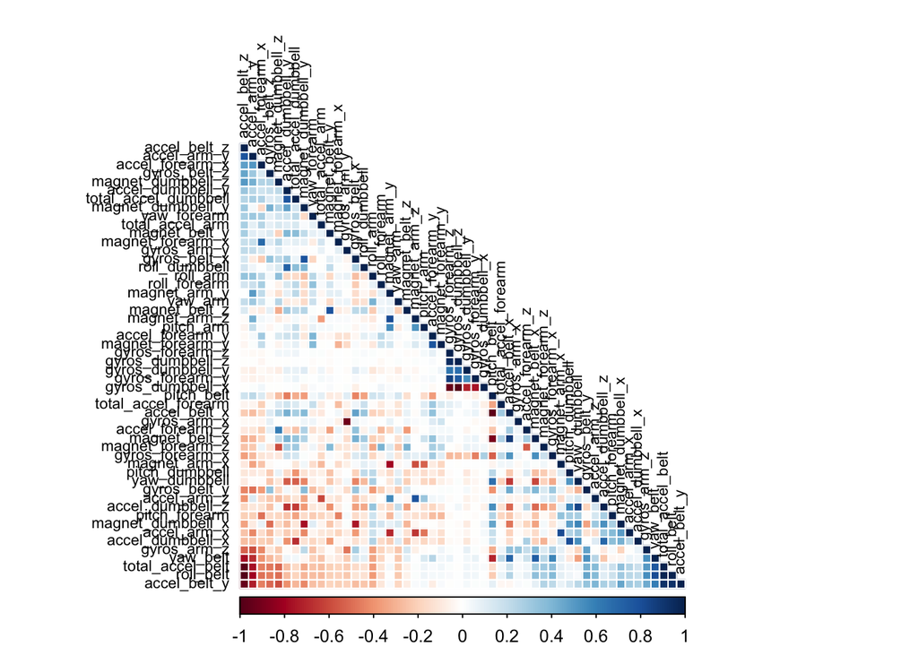

```r
library(corrplot)
cMat <- cor(subset(training, select=-c(classe)))
corrplot(cMat, order = "FPC", method = "color", type = "lower", tl.col = rgb(0, 0, 0), tl.cex = 0.7)
```

# Training and using the model

Let’s try a random forest and see how accurate that is. We will use cross-validation and not boot as the method for trainControl or we will be waiting a while.

```r
ctrl <- trainControl(allowParallel=T, method="cv", number=5)
rfmodel <- train(classe ~ ., data=training, method="rf", trControl=ctrl)
```

Having trained the model, let’s get some information about the result like the top 20 variables in order of importance and the confusion matrix.

```r
varImp(rfmodel)
```

```
## rf variable importance
##
##   only 20 most important variables shown (out of 52)
##
##                      Overall
## roll_belt             100.00
## pitch_forearm          57.33
## yaw_belt               52.47
## pitch_belt             44.78
## magnet_dumbbell_y      43.62
## roll_forearm           42.55
## magnet_dumbbell_z      41.55
## accel_dumbbell_y       21.85
## accel_forearm_x        17.04
## magnet_dumbbell_x      16.35
## magnet_belt_z          15.59
## roll_dumbbell          15.52
## magnet_forearm_z       14.23
## accel_dumbbell_z       13.14
## total_accel_dumbbell   13.01
## accel_belt_z           12.25
## magnet_belt_y          11.87
## gyros_belt_z           10.42
## yaw_arm                10.22
## magnet_belt_x           9.74
```

```r
rfmodel$finalModel$confusion
```

```
##      A    B    C    D    E class.error
## A 4458    4    1    0    1    0.001344
## B   17 3015    6    0    0    0.007571
## C    0   11 2714   13    0    0.008766
## D    0    0   24 2545    4    0.010882
## E    0    2    5    8 2871    0.005198
```

Okay, looks good but what about making some predictions and looking at that confusion matrix

```r
rfpred <- predict(rfmodel, newdata=testing)
sum(rfpred == testing$classe) / length(rfpred)
```

```
## [1] 0.9926
```

```r
confusionMatrix(testing$classe, rfpred)$table
```

```
##           Reference
## Prediction    A    B    C    D    E
##          A 1113    3    0    0    0
##          B   10  746    3    0    0
##          C    0    3  679    2    0
##          D    0    0    6  636    1
##          E    0    0    1    0  720
```

# Predicted Results

Now for the real meat, what are the predictions for the assignment questions?

```r
realtest <- rawTest[,!sapply(rawTest,function(x) any(is.na(x)))]
realtest <- subset(realtest, select=-c(X, user_name, new_window, num_window, raw_timestamp_part_1, raw_timestamp_part_2, cvtd_timestamp))
predict(rfmodel, newdata=realtest)
```

```
##  [1] B A B A A E D B A A B C B A E E A B B B
## Levels: A B C D E
```